# Getting Started · Corleone.jl

## Linear Quadratic Regulator

\[\begin{aligned} \min_u & \int_0^T w_1 (x - x_f)^2 + w_2 u^2 dt \\ \text{s.t.} \quad & \dot{x} = a x + b u \end{aligned}\]

First, we load the necessary packages to model the problem.

## Setup

We will use `Corleone` to define our optimal control problem.

```julia
using Corleone
```

Additionally, we will need the following packages

- `LuxCore` and `Random` for basic setup functions
- `OrdinaryDiffEqTsit5` as an adaptive solver for the related ODEProblem
- `Optimization`, `OptimizationLBFGSB`, and `ComponentArrays` to setup and solve the optimization problem
- `CairoMakie` to plot the solution

```julia
using LuxCore
using Random
using OrdinaryDiffEqTsit5
using Optimization
using OptimizationLBFGSB
using ForwardDiff
using ComponentArrays
using CairoMakie
```

## LQR Dynamics

Next, we set up the dynamics and the objective as a single function.

```julia
function lqr_dynamics(x, p, t)
    a, b, u = p
    du = a .* x[1] .+ b .* u
    costs = 10.0 .* (x[1] .- 3.0) .^ 2 .+ 0.1 .* u .^ 2
    return vcat(du, costs)
end

tspan = (0.0, 12.0)
u0 = [1.0, 0.0]
p0 = [-1.0, 1.0, 0.0]
lqr_problem = ODEProblem(lqr_dynamics, u0, tspan, p0)
```

```
ODEProblem with uType Vector{Float64} and tType Float64. In-place: false
Non-trivial mass matrix: false
timespan: (0.0, 12.0)
u0: 2-element Vector{Float64}:
 1.0
 0.0
```

## Optimal Control Problem

To convert this into an optimal control problem, we want to apply a piecewise constant control

```julia
control_function = ControlParameter(
    0.0:0.1:11.9, name = :input
)

predictor = SingleShootingLayer(
    lqr_problem, Tsit5(),
    controls = (3 => control_function,),
    bounds_p = ([-1.0, 1.0], [-1.0, 1.0])
)
```

```
SingleShootingLayer with 1 controls.
Underlying problem: ODEProblem with uType Vector{Float64} and tType Float64. In-place: false
Non-trivial mass matrix: false
timespan: (0.0, 12.0)
u0: 2-element Vector{Float64}:
 1.0
 0.0
```

Lets solve the problem to have a look at its initial behavior.

```julia
ps, st = LuxCore.setup(Random.default_rng(), predictor)
solution, _ = predictor(nothing, ps, st)
```

[output not shown]

We define a plotting function here

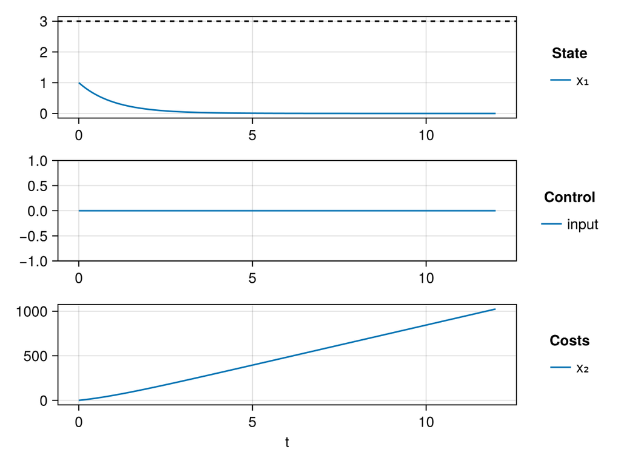

```julia
function plot_lqr_solution(solution; show_setpoint = true)
    f = Figure()
    axes = [CairoMakie.Axis(f[i, 1], xlabel = i == 3 ? "t" : "") for i in 1:3]
    plot!(axes[1], solution, vars = [:x₁])
    if show_setpoint
        hlines!(axes[1], [3.0], color = :black, linestyle = :dash)
    end
    stairs!(axes[2], solution, vars = [:input])
    plot!(axes[3], solution, vars = [:x₂])
    for (i, title) in enumerate(["State", "Control", "Costs"])
        f[i, 2] = Legend(f, axes[i], title, framevisible = false)
    end
    return f
end

plot_lqr_solution(solution)
```

## Optimize

Transforming the given layer into an [`SciMLBase.OptimizationProblem`](https://docs.sciml.ai/Optimization/stable/API/optimization_problem/#SciMLBase.OptimizationProblem) is a one liner. We simply give in the predictor and the cost to minimize.

```julia
optprob = OptimizationProblem(
    predictor, AutoForwardDiff(), Val(:ComponentArrays), loss = :x₂
);
```

```
┌ Info: 122
└   extrema(tpoints) = (0.0, 12.0)
```

And solve it using [`OptimizationLBFGSB.LBFGSB`](https://docs.sciml.ai/Optimization/stable/optimization_packages/lbfgsb/#OptimizationLBFGSB.LBFGSB)

```julia
uopt = solve(
    optprob, OptimizationLBFGSB.LBFGSB()
);
```

Finally, lets have a look at the optimized solution.

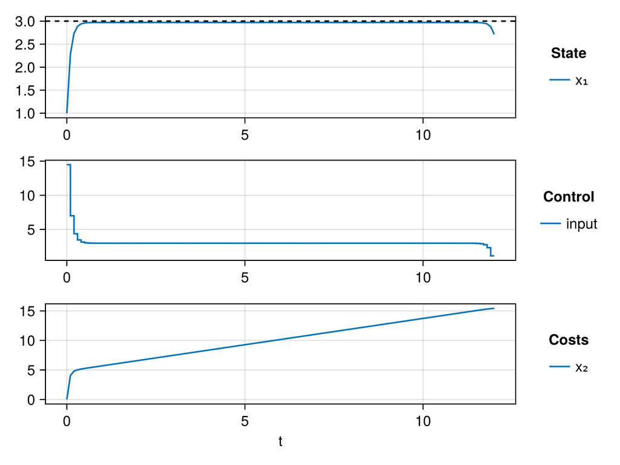

```julia
optimized_solution, _ = predictor(nothing, uopt + zero(ComponentArray(ps)), st)
plot_lqr_solution(optimized_solution)
```

## Appendix

**This example was built using these direct dependencies,**

```julia
        using Pkg
        Pkg.status()
```

```
Status `~/work/Corleone.jl/Corleone.jl/docs/Project.toml`
  [13f3f980] CairoMakie v0.15.8
  [b0b7db55] ComponentArrays v0.15.32
  [2751e0db] Corleone v0.0.3 `~/work/Corleone.jl/Corleone.jl`
  [6590a4b1] CorleoneOED v0.0.2
  [e30172f5] Documenter v1.16.1
  [daee34ce] DocumenterCitations v1.4.1
  [d12716ef] DocumenterInterLinks v1.1.0
  [f6369f11] ForwardDiff v1.3.2
  [b6b21f68] Ipopt v1.14.0
  [682c06a0] JSON v1.4.0
  [98b081ad] Literate v2.21.0
  [bb33d45b] LuxCore v1.5.3
  [961ee093] ModelingToolkit v11.10.0
  [7f7a1694] Optimization v5.5.0
  [22f7324a] OptimizationLBFGSB v1.4.0
  [fd9f6733] OptimizationMOI v1.2.0
  [b1df2697] OrdinaryDiffEqTsit5 v1.9.0
  [2efcf032] SymbolicIndexingInterface v0.3.46
  [ddb6d928] YAML v0.4.16
  [9a3f8284] Random v1.11.0
```

**and using this machine and Julia version.**

```julia
        using InteractiveUtils
        InteractiveUtils.versioninfo()
```

```
Julia Version 1.12.5
Commit 5fe89b8ddc1 (2026-02-09 16:05 UTC)
Build Info:
  Official https://julialang.org release
Platform Info:
  OS: Linux (x86_64-linux-gnu)
  CPU: 4 × AMD EPYC 7763 64-Core Processor
  WORD_SIZE: 64
  LLVM: libLLVM-18.1.7 (ORCJIT, znver3)
  GC: Built with stock GC
Threads: 1 default, 1 interactive, 1 GC (on 4 virtual cores)
```

**A more complete overview of all dependencies and their versions is also provided.**

```julia
        using Pkg
        Pkg.status(; mode = PKGMODE_MANIFEST)
```

[output not shown]

[output not shown]

*This page was generated using Literate.jl.*